# Trustworthy AI in Julia

The Alan Turing Institute

Patrick Altmeyer

Delft University of Technology

Delft University of Technology

[Patrick Altmeyer](https://www.patalt.org/)

2024-05-08

# Introduction

Economist by training, previously Bank of England, currently 3rd year PhD in Trustworthy AI @ TU Delft.

## Motivation

Why Trustworthy AI and why in Julia?

- Opaque AI technologies have entered the public domain with far-reaching stakes.
- These technologies are here to stay, so at best, we can make them more trustworthy.
- Julia has an edge:
  - **Transparency**: most packages are written in pure Julia.
  - **Intuitiveness**: great Lisp-like support for symbolic computing.
  - **Community**: welcoming, supportive and diverse (sort of!).
  - **Autodiff**: [top-notch support](https://discourse.julialang.org/t/automatic-differentiation-julia-implementation-advantages/24975), which helps with common XAI approaches.

## Outline

- **Taija**: A brief overview of the [Taija](https://github.com/JuliaTrustworthyAI) ecosystem.
  - Overview, Projects, Research.
- **Deep Dive**: A closer look at some of our core packages.
  - Counterfactual Explanations, Conformal Prediction, Laplace Redux, Joint Energy Models.
- **The Journey**: Julia throught my PhD
  - From “I’ll try this out” to “I’ll never go back”.

# Taija

Taija is the organization that hosts software geared towards Trustworthy Artificial Intelligence in Julia.

[figure not shown]

## Overview

#### Core Packages

- Model Explainability (CounterfactualExplanations.jl)
- Predictive Uncertainty Quantification (ConformalPrediction.jl)
- Effortless Bayesian Deep Learning (LaplaceRedux.jl)

#### Meta Packages

- Plotting (TaijaPlotting.jl)
- Datasets for testing and benchmarking (TaijaData.jl)
- Parallelization (TaijaParallel.jl)
- Interoperability with other programming languages (TaijaInteroperability.jl)

The TaijaBase.jl package provides common symbols, types and functions that are used across all or multiple Taija packages.

## Milestones

#### 2021

- First small-scale project in Julia on Bayesian regression.

## Milestones

#### 2022

- Presented `CounterfactualExplanations.jl` and `LaplaceRedux.jl` at JuliaCon.

#### 2021

- First small-scale project in Julia on Bayesian regression.

## Milestones

#### 2023

- Presented `ConformalPrediction.jl` at JuliaCon.
- TU Delft students work on `CounterfactualExplanations.jl` and `LaPlaceRedux.jl`.
- `CounterfactualExplanations.jl` published in JuliaCon proceedings.

#### 2022

- Presented `CounterfactualExplanations.jl` and `LaplaceRedux.jl` at JuliaCon.

#### 2021

- First small-scale project in Julia on Bayesian regression.

## Milestones

#### 2024

- Multiple presentations at JuliaCon this summer.
- GSoC/JSoC projects on Causal Counterfactuals and Conformal Bayes.
- TU Delft students working on `TaijaInteractive.jl`.

#### 2023

- Presented `ConformalPrediction.jl` at JuliaCon.
- TU Delft students work on `CounterfactualExplanations.jl` and `LaPlaceRedux.jl`.
- `CounterfactualExplanations.jl` published in JuliaCon proceedings.

#### 2022

- Presented `CounterfactualExplanations.jl` and `LaplaceRedux.jl` at JuliaCon.

#### 2021

- First small-scale project in Julia on Bayesian regression.

## Research

Taija has been used in the following publications:

- *Conformal Intent Classification and Clarification for Fast and Accurate Intent Recognition* (Hengst et al. 2024) [upcoming](https://arxiv.org/abs/2403.18973) in ACL’s NAACL Findings 2024<sup>1</sup>.
- *Faithful Model Explanations through Energy-Constrained Conformal Counterfactuals* (Altmeyer et al. 2024) [published](https://ojs.aaai.org/index.php/AAAI/article/view/28956) in Proceedings of the AAAI Conference on Artificial Intelligence 2024.
- *Explaining Black-Box Models through Counterfactuals* (Altmeyer, Deursen, et al. 2023) [published](https://proceedings.juliacon.org/papers/10.21105/jcon.00130) in JuliaCon Proceedings.
- *Endogenous Macrodynamics in Algorithmic Recourse* (Altmeyer, Angela, et al. 2023) [published](https://ieeexplore.ieee.org/abstract/document/10136130) in Proceedings of the 2023 IEEE Conference on Secure and Trustworthy Machine Learning (SaTML).
[^1]: Experiments were run in parallel using Python’s MAPIE and ConformalPrediction.jl, in order to cross-check results. Reported results were produced using MAPIE.

# Counterfactual Explanations

`CounterfactualExplanations.jl`: A [package](https://github.com/JuliaTrustworthyAI/CounterfactualExplanations.jl) for Counterfactual Explanations and Algorithmic Recourse in Julia.

[figure not shown]

## Background

$$\begin{aligned}
\min_{\mathbf{Z}^\prime \in \mathcal{Z}^L} \{ {\text{yloss}(M_{\theta}(f(\mathbf{Z}^\prime)),\mathbf{y}^+)} + \lambda {\text{cost}(f(\mathbf{Z}^\prime)) } \}
\end{aligned}$$

**Counterfactual Explanations** (CE) explain how inputs into a model need to change for it to produce different outputs.

📜 Altmeyer, Deursen, et al. (2023) @ JuliaCon 2022.

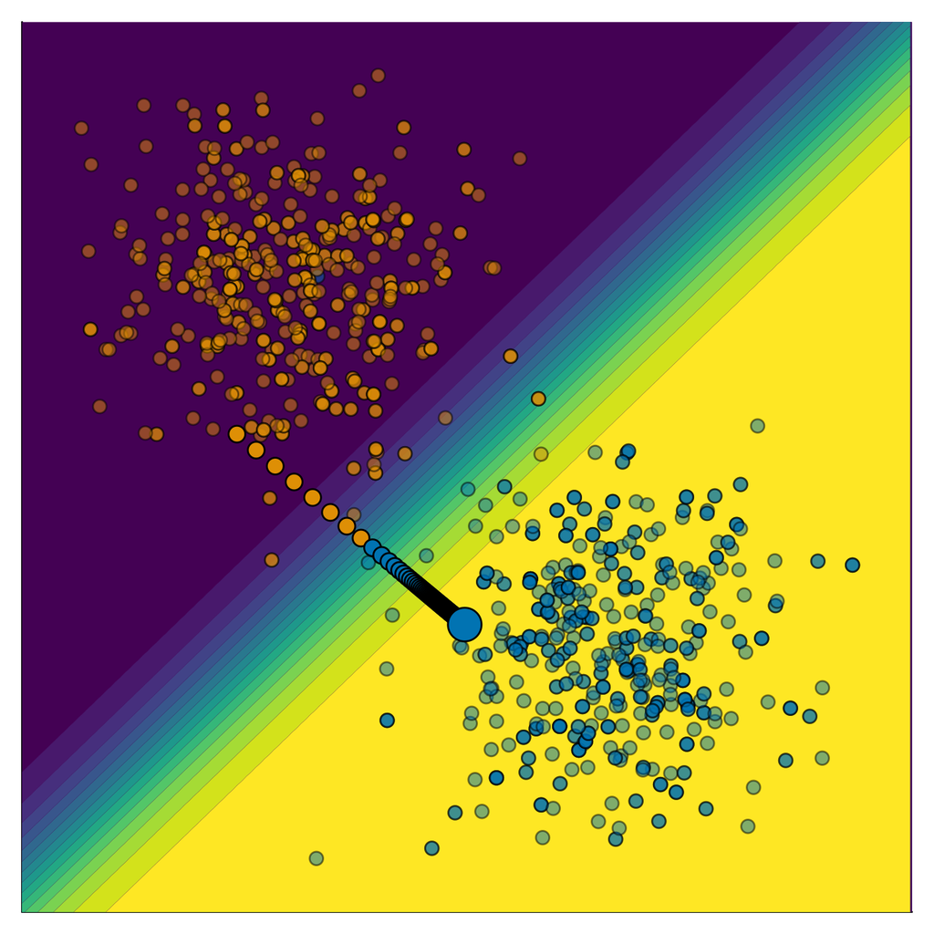

Figure 1: Gradient-based counterfactual search.

## Examples

- A motivating [example](https://juliatrustworthyai.github.io/CounterfactualExplanations.jl/stable/#Example:-Give-Me-Some-Credit).
- A simple usage example.
- Whistle-stop tour of different generators [here](https://juliatrustworthyai.github.io/CounterfactualExplanations.jl/stable/tutorials/whistle_stop/).
- Composing a custom generator using simple macros [here](https://juliatrustworthyai.github.io/CounterfactualExplanations.jl/stable/#Example:-MNIST).
- Scaling things up with parallelization [here](https://juliatrustworthyai.github.io/CounterfactualExplanations.jl/stable/tutorials/parallelization/).
- Extension for differentiable tree-based models [here](https://juliatrustworthyai.github.io/CounterfactualExplanations.jl/stable/extensions/neurotree/).

## Pick your Poison

All of these counterfactuals are valid explanations for the model’s prediction.

> Which one would you pick?

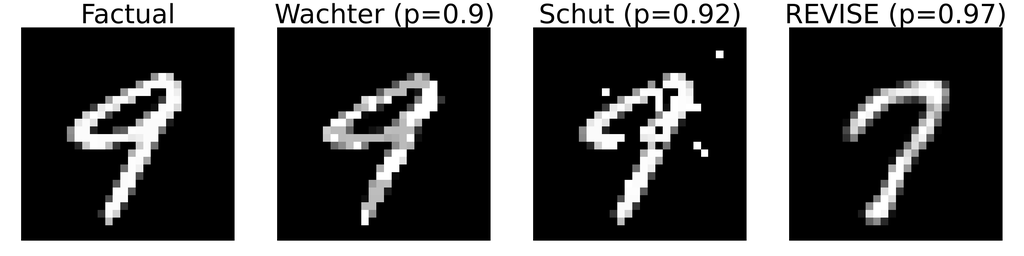

Figure 2: Turning a 9 into a 7: Counterfactual explanations for an image classifier produced using *Wachter* (Wachter et al. 2017), *Schut* (Schut et al. 2021) and *REVISE* (Joshi et al. 2019).

## ECCCos from the Black-Box

📜 Altmeyer, Farmanbar, et al. (2023) @ AAAI 2024

**Key Idea**

Use the hybrid objective of joint energy models (JEM) and a model-agnostic penalty for predictive uncertainty: Energy-Constrained ($\mathcal{E}_{\theta}$) Conformal ($\Omega$) Counterfactuals (*ECCCo*).

*ECCCo* objective<sup>1</sup>:

$$\begin{aligned}
& \min_{\mathbf{Z}^\prime \in \mathcal{Z}^L} \{ {L_{\text{clf}}(f(\mathbf{Z}^\prime);M_{\theta},\mathbf{y}^+)}+ \lambda_1 {\text{cost}(f(\mathbf{Z}^\prime)) } \\
&+ \lambda_2 \mathcal{E}_{\theta}(f(\mathbf{Z}^\prime)|\mathbf{y}^+) + \lambda_3 \Omega(C_{\theta}(f(\mathbf{Z}^\prime);\alpha)) \}
\end{aligned}$$

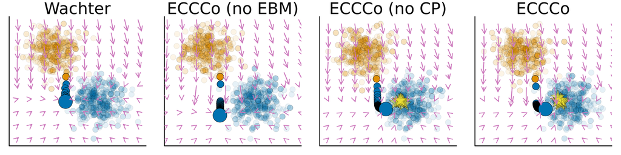

Figure 3: Gradient fields and counterfactual paths for different generators.

[^2]: We leverage ideas from Grathwohl et al. (2020) and Stutz et al. (2022). See the paper and appendix for a derivation of the objective from first principles.

## Faithful Counterfactuals

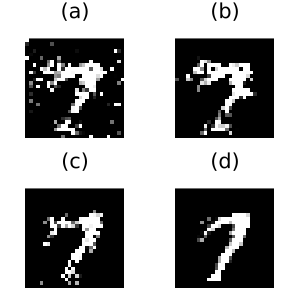

Figure 4: Turning a 9 into a 7. *ECCCo* applied to MLP (a), Ensemble (b), JEM (c), JEM Ensemble (d).

*ECCCo* generates counterfactuals that

- faithfully represent model quality (Figure 4).
- achieve state-of-the-art plausibility (Figure 5).

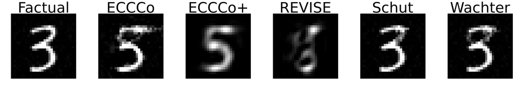

Figure 5: Results for different generators (from 3 to 5).

## Ongoing Work

- JSoC 2024: *From Counterfactuals to Interventions - Recourse through Minimal Causal Interventions* with Jorge Luiz Franco and co-mentor [Moritz Schauer](https://github.com/mschauer) (CausalInference.jl)
  - We typically make the implicit causal assumption that all features are independent.
  - If we have (imperfect) causal knowledge, we can use it to guide the search for counterfactuals.
- *What Makes Models Explainable?*: using *ECCCo* to benchmark models.
- Four master’s theses all using `CounterfactualExplanations.jl` (LLM explainability, imbalanced data, recourse in practice and counterfactuals for model testing).

# Conformal Prediction

`ConformalPrediction.jl`: A [package](https://github.com/JuliaTrustworthyAI/ConformalPrediction.jl) for Predictive Uncertainty Quantification through Conformal Prediction for Machine Learning models trained in MLJ.

[figure not shown]

## Background

Intuitively, CP works under the premise of turning heuristic notions of uncertainty into rigorous uncertainty estimates through repeated sampling or the use of dedicated calibration data.

[figure not shown]

Conformal Prediction in action: prediction intervals at varying coverage rates. As coverage grows, so does the width of the prediction interval.

## Examples

- A simple usage [example](https://juliatrustworthyai.github.io/ConformalPrediction.jl/stable/#Usage-Example).
- Conformalizing an image classifier [here](https://juliatrustworthyai.github.io/ConformalPrediction.jl/stable/how_to_guides/mnist/).
- How to build a conformal chatbot [here](https://juliatrustworthyai.github.io/ConformalPrediction.jl/stable/how_to_guides/llm/).

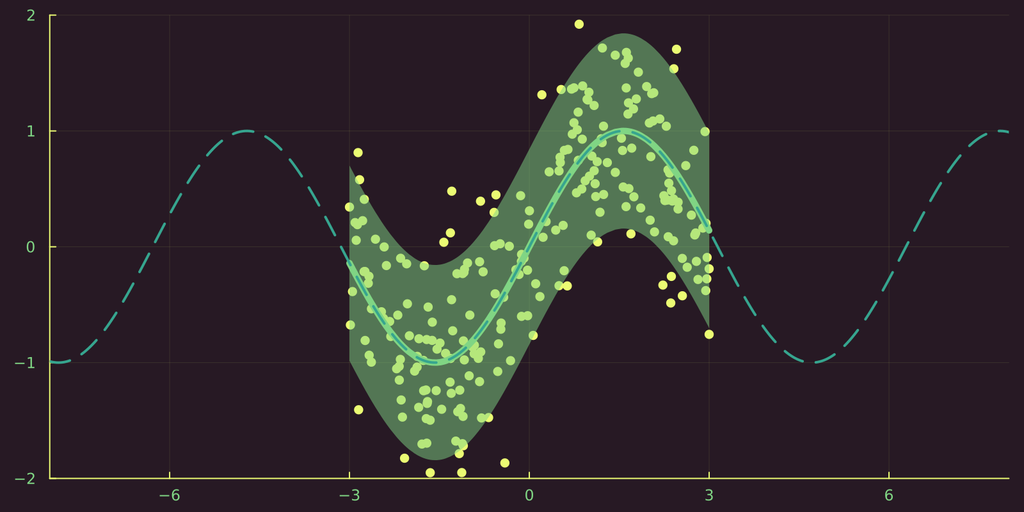

`ConformalPrediction.jl` meets `SymbolicRegression.jl`.

## Ongoing Work

- GSoC 2024: *Add the support to Conformal Bayes to Taija* with Pasquale Caterino and co-mentor Mojtaba Farmanbar
- Support for conformal training (Stutz et al. 2022).
- Code refactoring to allow adding support for parallelization using `TaijaParallel.jl`.
- JuliaCon Proceedings paper (in planning).

## Interactive Tour

… if time permits at the end.

> First time here? Take a quick interactive [tour](https://juliahub.com/ui/Notebooks/juliahub/Tutorials/ConformalPrediction.jl) to see what this package can do right on [JuliaHub](https://juliahub.com/ui/Notebooks/juliahub/Tutorials/ConformalPrediction.jl) (To run the notebook, hit login and then edit).

This [`Pluto.jl`](https://github.com/fonsp/Pluto.jl) 🎈 notebook won the 2nd Price in the [JuliaCon 2023 Notebook Competition](https://info.juliahub.com/pluto-notebook-winner-23).

# Laplace Redux

`LaplaceRedux.jl`: A [package](https://github.com/JuliaTrustworthyAI/LaplaceRedux.jl) for Effortless Bayesian Deep Learning through Laplace Approximation for Flux.jl neural networks.

[figure not shown]

## Background

We want BMA for neural networks underspecified by the data (Wilson 2020),

$$p(y|x,\mathcal{D}) = \int p(y|x,\theta)p(\theta|\mathcal{D})d\theta
\tag{1}$$

where $p(y|x,\theta)$ is the likelihood, $p(\theta|\mathcal{D})$ is the posterior and $\mathcal{D}$ is the training data.

- **Problem** 😢: Intractable posterior $p(\theta|\mathcal{D})$.
- **Convention** 🤔: Use MAP estimate $p(y|x,\mathcal{D}) \approx p(y|x,\hat\theta)$ with $\hat\theta=\arg\max_{\theta}p(\theta|\mathcal{D})$.
- **Idea** 💡: Taylor approximation at the mode amounts to multivariate Gaussian centered around MAP.

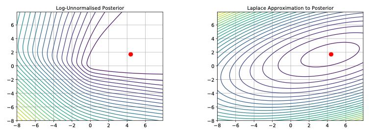

Unnormalized log-posterior and corresponding Laplace Approximation. Source: Murphy (2022).

## Model Assumptions

**Example (binary classification)**: We assume Bernoulli likelihood and a Gaussian prior for our weights …

$$p(y_n|\mathbf{x}_n;\mathbf{w})\sim\text{Ber}(y_n|\sigma(\mathbf{w}^T\mathbf{x}_n))
\tag{2}$$

$$p(\theta) \sim \mathcal{N} \left( \theta | \mathbf{0}, \lambda^{-1} \mathbf{I} \right)=\mathcal{N} \left( \theta | \mathbf{0}, \mathbf{H}_0^{-1} \right)
\tag{3}$$

… which yields the following negative log-likelihood (or energy) function (Murphy 2022):

$$\psi(\theta)= - \sum_{n}^N [y_n \log \mu_n + (1-y_n)\log (1-\mu_n)] + \\ \frac{1}{2} (\theta-\theta_0)^T\mathbf{H}_0(\theta-\theta_0)
\tag{4}$$

## Taylor Expansion

We have the following normalized posterior:

$$p(\theta|\mathcal{D}) = Z^{-1} p(\mathcal{D}|\theta)p(\theta) = Z^{-1} \exp(-\psi(\theta))
\tag{5}$$

with $Z = \int p(\mathcal{D}|\theta) p(\theta)$.

$$\psi(\theta) \approxeq \psi(\hat\theta) + \frac{1}{2} (\theta-\hat\theta)^T \mathbf{H}(\theta-\hat\theta)
\tag{6}$$

Thus, we have

$$p(\theta|\mathcal{D}) \approxeq \mathcal{N}(\theta;\hat\theta,-\mathbf{H}^{-1})
\tag{7}$$

## Hessian Approximation

- Challenge lies in computing the Hessian $\mathbf{H}$.
- We can use the Empirical Fisher or Generalized Gauss-Newton approximation (Murphy 2022).
  - Still quadratic in the number of parameters.
- For scalable solutions, we can use the diagonal approximation or the K-FAC approximation or work with a subnetwork.

## Examples

- A basic usage [example](https://juliatrustworthyai.github.io/LaplaceRedux.jl/stable/#Basic-Usage).
- A binary classification [example](https://juliatrustworthyai.github.io/LaplaceRedux.jl/stable/#Binary-Classification) with prior tuning through empirical Bayes.
- Counterfactual explanations with Laplace Redux [here](https://juliatrustworthyai.github.io/CounterfactualExplanations.jl/stable/extensions/laplace_redux/).

[figure not shown]

# Joint Energy Models

`JointEnergyModels.jl`: A [package](https://github.com/JuliaTrustworthyAI/JointEnergyModels.jl?tab=readme-ov-file) for Joint Energy Models and Energy-Based Models in Julia.

[figure not shown]

## Background

**Joint Energy Models** (JEM) are a class of energy-based models that learn a joint distribution over inputs and outputs (Grathwohl et al. 2020).

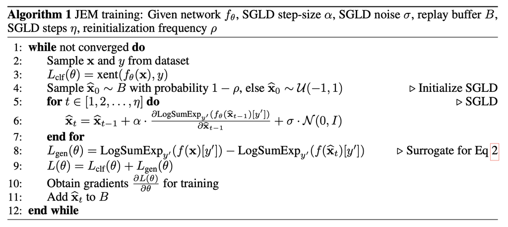

Training JEMs.

## Package

- Package used in Altmeyer et al. (2024), but less mature than the other packages.
- Simple usage example can be found [here](https://juliatrustworthyai.github.io/JointEnergyModels.jl/stable/).

> Contributions welcome!

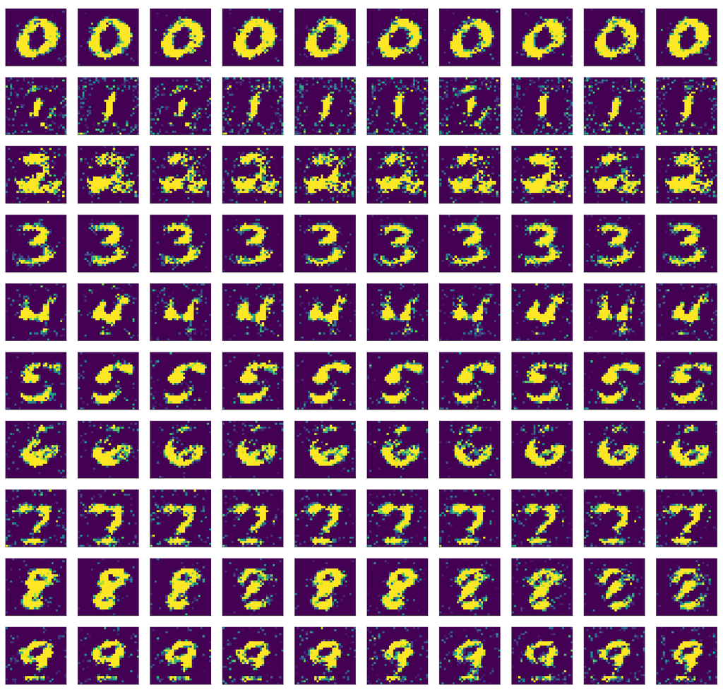

Samples generated through SGLD for JEM ensemble.

# The Journey

## Timeline

- Background in R and Python (mostly R), a little bit of MATLAB during my master’s
- First looked at Julia (`v0.6`) in 2017 during my master’s but quickly abandoned it.
- During my master’s in Data Science (2021) I started to get frustrated with the speed of R and Python.
  - Did some work in C++ and Rcpp, but it was too cumbersome.
- Started my PhD in Trustworthy AI in September 2021 and decided to give Julia another go.
- Haven’t looked back since!

## The Bad

- Expect to implement things from scratch (not always a bad thing!).
- Some important packages are still in development and lack contributors (e.g. `Transformers.jl`).
- I’m still sometimes puzzled by implicit imports (and I know my students are too!).
- AI research is still dominated by Python/R, so developing in Julia does not always feel impactful.

# Questions?

## References

Altmeyer, Patrick, Giovan Angela, Aleksander Buszydlik, Karol Dobiczek, Arie van Deursen, and Cynthia C. S. Liem. 2023. “Endogenous Macrodynamics in Algorithmic Recourse.” *2023 IEEE Conference on Secure and Trustworthy Machine Learning (SaTML)*, 418–31. https://doi.org/10.1109/satml54575.2023.00036.

Altmeyer, Patrick, Arie van Deursen, and Cynthia C. S. Liem. 2023. “Explaining Black-Box Models through Counterfactuals.” *Proceedings of the JuliaCon Conferences* 1: 130. https://doi.org/10.21105/jcon.00130.

Altmeyer, Patrick, Mojtaba Farmanbar, Arie van Deursen, and Cynthia C. S. Liem. 2023. *Faithful Model Explanations Through Energy-Constrained Conformal Counterfactuals*. https://arxiv.org/abs/2312.10648.

Altmeyer, Patrick, Mojtaba Farmanbar, Arie van Deursen, and Cynthia C. S. Liem. 2024. “Faithful Model Explanations through Energy-Constrained Conformal Counterfactuals.” *Proceedings of the Thirty-Eighth AAAI Conference on Artificial Intelligence* 38: 10829–37. https://doi.org/10.1609/aaai.v38i10.28956.

Grathwohl, Will, Kuan-Chieh Wang, Joern-Henrik Jacobsen, David Duvenaud, Mohammad Norouzi, and Kevin Swersky. 2020. “Your Classifier Is Secretly an Energy Based Model and You Should Treat It Like One.” *International Conference on Learning Representations*.

Hengst, Floris, Ralf Wolter, Patrick Altmeyer, and Arda Kaygan. 2024. “Conformal Intent Classification and Clarification for Fast and Accurate Intent Recognition.” *Findings of the Association for Computational Linguistics: NAACL 2024*, 2412–32. https://doi.org/10.18653/v1/2024.findings-naacl.156.

Joshi, Shalmali, Oluwasanmi Koyejo, Warut Vijitbenjaronk, Been Kim, and Joydeep Ghosh. 2019. *Towards Realistic Individual Recourse and Actionable Explanations in Black-Box Decision Making Systems*. https://arxiv.org/abs/1907.09615.

Murphy, Kevin P. 2022. *Probabilistic Machine Learning: An Introduction*. MIT Press.

Schut, Lisa, Oscar Key, Rory McGrath, et al. 2021. “Generating Interpretable Counterfactual Explanations By Implicit Minimisation of Epistemic and Aleatoric Uncertainties.” *International Conference on Artificial Intelligence and Statistics*, 1756–64.

Stutz, David, Krishnamurthy, Dvijotham, Ali Taylan Cemgil, and Arnaud Doucet. 2022. *Learning Optimal Conformal Classifiers*. https://arxiv.org/abs/2110.09192.

Wachter, Sandra, Brent Mittelstadt, and Chris Russell. 2017. “Counterfactual Explanations Without Opening the Black Box: Automated Decisions and the GDPR.” *Harv. JL & Tech.* 31: 841. https://doi.org/10.2139/ssrn.3063289.

Wilson, Andrew Gordon. 2020. *The Case for Bayesian Deep Learning*. https://arxiv.org/abs/2001.10995.